# Intuit Trees and Nets

- Team-lead GitLab id: rsm-wel030
- Group number: Group 10
- Group name: Group 10
- Team member names: Wenrui Li, Shumeng Shi, Menghui Zhang

### Setup

Please complete this R-markdown document with your group by working through the guidelines in `intuit-trees-nets.pdf` on Dropbox (week7/readings/). Create an HTML file with all your results and comments and push both the Rmarkdown and HTML file to GitLab when your team is done. All results MUST be reproducible (i.e., the TA and I must be able to recreate the HTML from the Rmarkdown file without changes or errors). Also, make sure the code is well commented and formatted (e.g., use styler through Addins > Style active file in Rstudio).

This is the second group assignment for MGTA 455 and you will be using git and GitLab. If two people edit the same file at the same time you could get what is called a “merge conflict”. git will not decide for you who’s change to accept so the team-lead will have to determine which edits to use. To avoid merge conflicts, always click “pull” in Rstudio before you start working on file. Then, when you are done, commit your changes, and push them to GitLab. Make this a habit!

If multiple people are going to work on the assignment at the same time I recommend you work on different files. You can use `source` to include R-code in your Rmarkdown document or include other R(markdown) documents into the main assignment file.

Group work-flow tips are listed from ICT in summer are shown below:

- Pull, edit, save, stage, commit, and push
- Schedule who does what and when
- Try to avoid working simultaneously on the same file
- If you are going to work simultaneously, do it in different files, e.g.,
  - assignment1_john.R, assignment1_susan.R, assignment1_wei.R
  - assignment1a.R, assignment1b.R, assignment1c.R
- Use the ‘source’ command to bring different pieces of code together in an Rmarkdown document or in an R-code file
- Alternatively, use *child* in Rmarkdown to include a part of a report
- For (very) big projects use ‘branches’ to avoid conflicts (and stay on your branch)

A graphical depiction of the group work-flow is shown below:

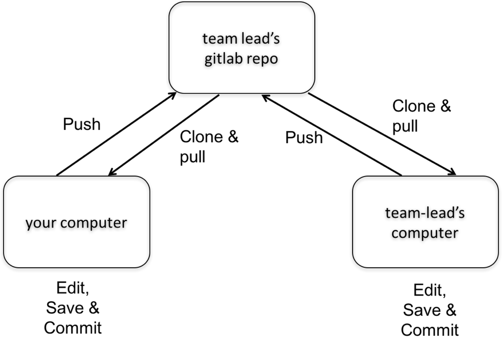

Additional resource on the use of git are linked below:

- http://happygitwithr.com
- http://r-pkgs.had.co.nz/git.html
- http://stackoverflow.com/questions/tagged/git or just a google search
- https://try.github.io
- https://www.manning.com/books/git-in-practice
- https://github.com/GitInPractice/GitInPractice#readme

### Data file import and pre-processing

```r
## loading the data. Note that data must be loaded from Dropbox/MGTA455-2019/data
intuit75k <- readr::read_rds(file.path(radiant.data::find_dropbox(), "MGTA455-2019/data/intuit75k.rds"))

## change variable types for 5 factor variables
intuit75k <- mutate_at(intuit75k, .vars = vars(zip_bins, bizflag, version1, owntaxprod, upgraded), .funs = funs(as_factor))

### create 00801 and 00804 bin

intuit75k <- intuit75k %>%
  mutate(zip801 = ifelse(zip == "00801", "Yes", "No"),
         zip804 = ifelse(zip == "00804", "Yes", "No"))

intuit75k <- mutate_at(intuit75k, .vars = vars(zip801,zip804), .funs = funs(as_factor))

###split the data into train and test.


intuit75k_train <- intuit75k %>%
  filter(training == 1) %>%
  select(-id, -zip, -training) %>%
  mutate_if(is.character, as.factor) %>%
  mutate(res1 = as.factor(ifelse(res1 == "Yes",1,0)))

intuit75k_test <- intuit75k %>%
  filter(training == 0) %>%
  select(-id, -zip, -training) %>%
  mutate_if(is.character, as.factor) %>%
  mutate(res1 = as.factor(ifelse(res1 == "Yes",1,0)))
```

### Evaluation Functions

```r
mail_cost <- 1.41
margin_revenue <- 60
breakeven_rate <- mail_cost/margin_revenue

overall_val_resp <- intuit75k %>%
  filter(training == 0) %>%
  summarise(avg_resp = mean(res1 == "Yes")) %>%
  pull()


cm <- function(dat, vars){

  cm_df <- as.data.frame(matrix(NA, ncol = 3, nrow = length(vars)))
  colnames(cm_df) <- c("var", "auc", "tpr")

  for (i in 1:length(vars)){

    var <- vars[i]
    probs <- pull(dat, !!var)
    resp <- pull(dat, "res1")

    mailto <- ifelse(pull(dat, !!var) > breakeven_rate, "TRUE", "FALSE") # decide whether to mail or not

    tpr <- sum(resp == "Yes" & mailto == "TRUE")/sum(resp == "Yes")
    auc <- ModelMetrics::auc(ifelse(resp=="Yes",1,0), probs)

    cm_vec <- c(var, auc, tpr)
    cm_df[i,] <- cm_vec
  }
  return(cm_df)
}

model_eval <- function(dat, vars){

  # calculate expected scaled profits and ROME

  eval_df <- as.data.frame(matrix(NA, ncol = 6, nrow = length(vars)))
  colnames(eval_df) <- c("var","nr_mail", "rep_rate_w2", "nr_resp_w2", "profit", "ROME")


  for (i in 1:length(vars)){

    var <- vars[i]

    mailto <- ifelse(pull(dat, !!var) > 2 * breakeven_rate, "TRUE", "FALSE") # decide whether to mail or not
    mailto_rate <- mean(mailto == "TRUE")
    nr_mail <- mailto_rate * (801821 - 38487) #target size

    resp <- pull(dat, "res1") # extract respondents

    rep_rate_w1 <- sum(resp == "Yes" & mailto == "TRUE")/sum(mailto=="TRUE") # response rate among targeted audience
    rep_rate_w2 <- rep_rate_w1 * 0.5
    nr_resp_w2 <- rep_rate_w2 * nr_mail # response customers among targeted audience

    sum_cost <- mail_cost * nr_mail
    revenue <- margin_revenue * nr_resp_w2
    profit <- revenue - sum_cost
    ROME <- profit/sum_cost

    perf_vec <- c(var, nr_mail, rep_rate_w2, nr_resp_w2, profit, ROME)

    eval_df[i,] <- perf_vec
  }

  eval_df[,2:6] <- lapply(eval_df[,2:6], as.numeric)
  return(eval_df)
}


# this function is to plot cumulative gain and cumulative lift charts
lift_gain_plot <- function(dat, vars){

  lift_gain_df <- as.data.frame(matrix(NA, ncol = 4))
  colnames(lift_gain_df) <- c("resp_decile", "cumulative_gain", "cumulative_lift", "var")

  for (i in 1:length(vars)){

    var <- vars[i]

    probs <- pull(dat, !!var)
    resp <- pull(dat, "res1")

    lg_dat <- data.frame(probs, resp)
    lg_dat <- lg_dat %>%
      mutate(resp_decile = xtile(probs, n = 10, rev = T)) %>%
      group_by(resp_decile) %>%
      summarise(n_customer = n(),
                n_buyer = sum(resp == "Yes")) %>%
      mutate(cum_customer = cumsum(n_customer),
             cum_buyer = cumsum(n_buyer),
             cumulative_lift = (cum_buyer/cum_customer)/overall_val_resp,
             cumulative_gain = cum_buyer/sum(n_buyer)) %>%
      select(resp_decile, cumulative_gain, cumulative_lift)

    lg_dat[,var] <- var

    lift_gain_df <- rbind(lift_gain_df, setNames(lg_dat, names(lift_gain_df)))
  }

  lift_gain_df <- lift_gain_df[-1,] #remove first null row
  lift_gain_df$prop_customer <- rep(seq(0.1,1, 0.1),length(vars))

  # plot cumulative lift
  p1 <- lift_gain_df %>%
    ggplot(aes(x = prop_customer, y = cumulative_lift, group = var)) +
    geom_point(aes(color = var)) + geom_line(aes(color = var))+
    geom_hline(yintercept = 1, color = "black")

  # plot cumulative gain
  p2 <- lift_gain_df %>%
    ggplot(aes(x = prop_customer, y = cumulative_gain, group = var)) +
    geom_point(aes(color = var)) + geom_line(aes(color = var))+
    geom_line(aes(y = prop_customer), color = "black")

  gridExtra::grid.arrange(p1,p2, nrow = 2)

}
```

### Random Forest

First we trained a random forest model with default parameters and saved predictions for later comparison.

```r
rf_model <- randomForest(formula = res1 ~ . , data = intuit75k_train, type = "classification")

pred <- predict(rf_model, newdata = intuit75k_test, type = "prob")
intuit75k_test$pred_rf_default <- pred[,2]
```

Next we tuned parameters including mtry, node side and sample size and tracked AUC of each model.

```r
# hyper parameter tuning
mtry <- seq(4, 10, 2)
nodesize <- seq(4,12,2)
sampsize <- nrow(intuit75k_train) * c(0.6, 0.7, 0.8, 0.9)

# build parameters matrix and keep auc performance
params <- expand.grid(mtry, nodesize, sampsize)
params$auc <- NA
colnames(params) <- c("mtry", "nodesize", "sampsize", "auc")

# train random forest models and keep track of test data performance
for (i in 1:nrow(params)){
  rf_tune <- randomForest(formula = res1 ~ . , data = intuit75k_train,
                          type = "classification", mtry = params[i,1], nodesize = params[i,2],
                          sampsize = params[i,3])

  pred_tune <- predict(rf_tune, newdata = intuit75k_test, type = "prob")
  auc <- auc(intuit75k_test$res1, pred_tune[,2])
  params[i,4] <- auc

}

saveRDS(params, "rf_tune.rds")
```

```r
# load the tune results and check top performers
rf_tune <- readRDS("data/rf_tune.rds")

rf_tune %>%
  top_n(auc, n = 5)
```

```
  mtry nodesize sampsize       auc
1    4        8    31500 0.7424312
2    6       10    31500 0.7400071
3    4       12    31500 0.7402575
4    4        6    36750 0.7396682
5    4       12    36750 0.7395428
```

Based on our previous tuning results, we split our parameters into smaller units and train our models.

```r
# hyper parameter tuning
mtry <- c(4,5,6)
nodesize <- seq(8,12,1)
sampsize <- nrow(intuit75k_train) * c(0.6, 0.7)

# build parameters matrix and keep auc performance
params2 <- expand.grid(mtry, nodesize, sampsize)
params2$auc <- NA
colnames(params2) <- c("mtry", "nodesize", "sampsize", "auc")

# train random forest models and keep track of test data performance
for (i in 1:nrow(params2)){
  rf_tune <- randomForest(formula = res1 ~ . , data = intuit75k_train,
                          type = "classification", mtry = params2[i,1], nodesize = params2[i,2],
                          sampsize = params2[i,3])

  pred_tune <- predict(rf_tune, newdata = intuit75k_test, type = "prob")
  auc <- auc(intuit75k_test$res1, pred_tune[,2])
  params2[i,4] <- auc

}

saveRDS(params2, "rf_tune2.rds")
```

```r
# load the tune results and check top performers
rf_tune2 <- readRDS("data/rf_tune2.rds")

rf_tune2 %>%
  top_n(auc, n = 5)
```

```
  mtry nodesize sampsize       auc
1    4        9    31500 0.7404145
2    5        9    31500 0.7402709
3    4       11    31500 0.7419989
4    4       12    31500 0.7407108
5    6       12    31500 0.7406911
```

After second round of hyperparameters tuning, we decide to use 5 top performing random forest models in terms of auc and calculate expected profits.

```r
optimal_params <- rf_tune2 %>%
  arrange(desc(auc)) %>%
  top_n(auc, n = 5) %>%
  select(-auc)

rf_preds <- matrix(NA, ncol = nrow(optimal_params), nrow = nrow(intuit75k_test))

for (i in 1:nrow(optimal_params)){
  rf_tune <- randomForest(formula = res1 ~ . , data = intuit75k_train,
                          type = "classification", mtry = optimal_params[i,1],
                          nodesize = optimal_params[i,2],
                          sampsize = optimal_params[i,3])

  pred_tune <- predict(rf_tune, newdata = intuit75k_test, type = "prob")

  rf_preds[,i] <- pred_tune[,2]
}

saveRDS(rf_preds, "data/rf_preds.rds")
```

```r
rf_preds <- readRDS("data/rf_preds.rds")

# cbind the predictions to intuit75_test dataframe and put into evaluations
colnames(rf_preds) <- paste0(rep("random_forest", 5), c(1:5))
intuit75k_test <- cbind(intuit75k_test, rf_preds)
intuit75k_test$res1 <- ifelse(intuit75k_test$res1 == 1, "Yes", "No")
vars <- tail(colnames(intuit75k_test), 6)

model_eval(intuit75k_test, vars)
```

```
              var  nr_mail rep_rate_w2 nr_resp_w2   profit     ROME
1 pred_rf_default 156195.1  0.06440052  10059.046 383307.7 1.740448
2  random_forest1 117146.3  0.07877208   9227.860 388495.3 2.352003
3  random_forest2 108970.2  0.07985679   8702.008 368472.5 2.398161
4  random_forest3 127256.3  0.07371368   9380.527 383400.3 2.136752
5  random_forest4 137773.3  0.07017976   9668.897 385873.5 1.986373
6  random_forest5 153141.8  0.06645990  10177.787 394737.3 1.828081
```

### Decision Tree - loosen the control

#### Data import

```r
## loading the data. Note that data must be loaded from the data/
## in the rstudio project directory
intuit75k <- readr::read_rds(file.path(radiant.data::find_dropbox(), "MGTA455-2019/data/intuit75k.rds"))
```

```r
## change variable types for 5 factor variables

intuit75k <- intuit75k %>%
  mutate(zip801 = ifelse(zip == "00801", "Yes", "No"),
         zip804 = ifelse(zip == "00804", "Yes", "No"))

intuit75k <- mutate_at(intuit75k, .vars = vars(zip_bins, bizflag, version1, owntaxprod, upgraded, zip801, zip804), .funs = funs(as.factor))

train = intuit75k %>%
  filter(training == 1)

test = intuit75k %>%
  filter(training == 0)
```

```r
decision_tree = rpart(formula = res1 ~ zip_bins + numords + dollars + last + version1 + owntaxprod + upgraded + zip801 + zip804, data = train, control=rpart.control(minsplit=2, minbucket=1, cp=0.001))

test$decision_tree_pred = predict(decision_tree, newdata = test, type = 'prob')
```

### Bagging

```r
bagging = bagging(formula = res1 ~  zip_bins + numords + dollars + last + version1 + owntaxprod + upgraded + zip801 + zip804, data = train, nbagg=50)
test$bagging_pred = predict(object = bagging, newdata = test, type = 'prob')
```

### Treebag cross-validation

```r
ctrl = trainControl(method = 'cv', number = 5)
treebag = train(res1 ~ zip_bins + numords + dollars + last + version1 + owntaxprod + upgraded + zip801 + zip804, data = train, method = 'treebag', trControl = ctrl)
test$treebag_pred = predict(object = treebag, newdata = test, type = 'prob')$`Yes`
```

### GBM - default setting

```r
test_gbm = test
train_gbm = train
train_gbm$res1 <- ifelse(train_gbm$res1 == "Yes", 1, 0)
test_gbm$res1 <- ifelse(test_gbm$res1 == "Yes", 1, 0)

gbm = gbm(formula = res1 ~  zip_bins + numords + dollars + last + version1 + owntaxprod + upgraded + zip801 + zip804, distribution = 'bernoulli', data = train_gbm, n.trees = 100)
test$gbm_pred = predict.gbm(object = gbm, newdata = test_gbm, type = 'response',n.trees = 100)
```

```r
vars_vec = c('decision_tree_pred','bagging_pred','treebag_pred','gbm_pred')

basic_model_eval = model_eval(test,vars_vec)
saveRDS(basic_model_eval, "data/basic_model_eval.rds")
cm(test,vars_vec)
```

```
                 var               auc               tpr
1 decision_tree_pred 0.586884156195628  1.99456029011786
2       bagging_pred  0.70147300794703  1.62647325475975
3       treebag_pred 0.677223076027087 0.602901178603808
4           gbm_pred 0.758465051171161 0.905711695376247
```

```r
basic_model_eval <- readRDS("data/basic_model_eval.rds")
basic_model_eval
```

```
                 var  nr_mail rep_rate_w2 nr_resp_w2   profit      ROME
1 decision_tree_pred 389741.4  0.02826863   11017.45 111511.9 0.2029203
2       bagging_pred 480289.8  0.03005580   14435.49 188921.1 0.2789703
3       treebag_pred 158603.8  0.05711230    9058.23 319862.4 1.4303106
4           gbm_pred 191240.6  0.06138017   11738.38 434653.6 1.6119220
```

The model with outstanding profits is gbm, so we will focus on tuning the hyparameters of this model.

### GBM - hyperparameter tuning

```r
# hyper parameter tuning
interaction.depth <- c(2,4,6)
shrinkage <- c(0.001, 0.01, 0.1)
cv.folds <- c(2,4,6)

# build parameters matrix and keep auc performance
params <- expand.grid(interaction.depth, shrinkage, cv.folds)
params$auc <- NA
colnames(params) <- c("interaction.depth", "shrinkage", "cv.folds", "auc")

train$res1 <- ifelse(train$res1 == "Yes", 1, 0)
test$res1 <- ifelse(test$res1 == "Yes", 1, 0)

train = train[,-c(1,2)]
test = test[,-c(1,2)]

# train gbm models and keep track of test data performance
for (i in 1:nrow(params)){
  set.seed(123)
  gbm_tune <- gbm(formula = res1 ~ . ,
                  data = train,
                  distribution = "bernoulli",
                  interaction.depth = params[i,1],
                  shrinkage = params[i,2],
                  cv.folds = params[i,3],
                  n.trees = 100)
  print(i)
  pred_tune <- predict(gbm_tune, newdata = test, type = "response", n.trees = 100)
  auc <- ModelMetrics::auc(test$res1, pred_tune)
  params[i,4] <- auc

}

saveRDS(params, "gbm_tune.rds")
```

```r
gbm_tune = readRDS("data/gbm_tune.rds")
gbm_tune %>%
  arrange(desc(auc)) %>%
  top_n(auc, n = 10)
```

```
   interaction.depth shrinkage cv.folds       auc
1                  4      0.10        6 0.7670463
2                  4      0.10        4 0.7668870
3                  2      0.10        6 0.7665095
4                  4      0.10        2 0.7661262
5                  6      0.10        4 0.7653023
6                  2      0.10        4 0.7652209
7                  2      0.10        2 0.7642660
8                  6      0.10        6 0.7639728
9                  6      0.10        2 0.7631310
10                 6      0.01        2 0.7557845
```

Based on our previous tuning results, we’ll split our parameters into smaller units and train our models.

```r
# hyper parameter tuning
interaction.depth <- c(3,4,5)
shrinkage <- c(0.07,0.08,0.09,0.1)
cv.folds <- c(6)

# build parameters matrix and keep auc performance
params2 <- expand.grid(interaction.depth, shrinkage, cv.folds)
params2$auc <- NA
colnames(params2) <- c("interaction.depth", "shrinkage", "cv.folds", "auc")

# train gbm models and keep track of test data performance
for (i in 1:nrow(params2)){
  set.seed(123)
  gbm_tune2 <- gbm(formula = res1 ~ . ,
                   data = train,
                   distribution = "bernoulli",
                   interaction.depth = params2[i,1],
                   shrinkage = params2[i,2],
                   cv.folds = params2[i,3],
                   n.trees = 100)
  print(i)
  pred_tune2 <- predict(gbm_tune2, newdata = test, type = "response", n.trees = 100)
  auc2 <- ModelMetrics::auc(test$res1,pred_tune2)
  params2[i,4] <- auc2

}

saveRDS(params2, "gbm_tune2.rds")
```

```r
params2 <- readRDS("data/gbm_tune2.rds")
params2 %>%
  arrange(desc(auc))
```

```
   interaction.depth shrinkage cv.folds       auc
1                  4      0.08        6 0.7684986
2                  4      0.09        6 0.7683600
3                  5      0.07        6 0.7682069
4                  5      0.08        6 0.7676321
5                  4      0.07        6 0.7676232
6                  3      0.10        6 0.7674366
7                  3      0.08        6 0.7672279
8                  5      0.10        6 0.7672206
9                  3      0.09        6 0.7671353
10                 4      0.10        6 0.7670463
11                 3      0.07        6 0.7665346
12                 5      0.09        6 0.7658654
```

After 2nd round of hyperparameters tuning, we decide to use 8 top performing gbm models in terms of auc and calculate expected profits, since higher AUC doesn’t necessarily mean higher profit.

```r
optimal_params_gbm <- params2 %>%
arrange(desc(auc)) %>%
top_n(auc, n = 8) %>%
select(-auc)

train_gbm = train_gbm[,-c(1,2)]
test_gbm = test_gbm[,-c(1,2)]

gbm_preds <- matrix(NA, ncol = nrow(optimal_params_gbm), nrow = nrow(test_gbm))

for (i in 1:nrow(optimal_params_gbm)){
set.seed(123)
gbm_tune <- gbm(formula = res1 ~ . ,
data = train_gbm,
distribution = "bernoulli",
interaction.depth = optimal_params_gbm[i,1],
shrinkage = optimal_params_gbm[i,2],
n.trees = 100)
print(i)
pred_tune <- predict(gbm_tune, newdata = test_gbm, type = "response", n.trees = 100)
gbm_preds[,i] <- pred_tune
}


# cbind the predictions to intuit75_test dataframe and put into evaluations
colnames(gbm_preds) <- paste(rep("gbm", 8), c(1:8))
test_gbm1 <- cbind(test_gbm, gbm_preds)

vars <- tail(colnames(test_gbm1), 8)
test_gbm1$res1 <- ifelse(test_gbm1$res1 == 1, 'Yes', 'No')

model_eval(test_gbm1, vars)
cm(test_gbm1, vars)
lift_gain_plot(test_gbm1, vars)
gbm_tune1_model_eval = model_eval(test_gbm1, vars)
saveRDS(gbm_tune1_model_eval, "data/gbm_tune1_model_eval.rds")
```

```r
gbm_tune1_model_eval <- readRDS("data/gbm_tune1_model_eval.rds")
gbm_tune1_model_eval[,2:6] <- lapply(gbm_tune1_model_eval[,2:6], as.numeric)
gbm_tune1_model_eval
```

```
    var  nr_mail rep_rate_w2 nr_resp_w2   profit     ROME
1 gbm 1 181334.2  0.06520112   11823.20 453710.5 1.774516
2 gbm 2 182352.0  0.06474419   11806.23 451257.6 1.755072
3 gbm 3 180587.9  0.06481308   11704.45 447638.4 1.758003
4 gbm 4 185201.8  0.06365635   11789.27 446221.6 1.708781
5 gbm 5 177839.9  0.06571919   11687.49 450495.3 1.796561
6 gbm 6 189612.2  0.06396493   12128.53 460358.6 1.721912
7 gbm 7 182453.8  0.06498698   11857.12 454167.4 1.765404
8 gbm 8 188967.6  0.06319569   11941.94 450071.9 1.689178
```

```r
optimal_params_gbm2 <- params2 %>%
arrange(desc(auc)) %>%
top_n(auc, n = 8) %>%
select(-auc)

gbm_preds2 <- matrix(NA, ncol = nrow(optimal_params_gbm2), nrow = nrow(test_gbm))

for (i in 1:nrow(optimal_params_gbm2)){
set.seed(123)
gbm_tune <- gbm(formula = res1 ~ . ,
data = train_gbm,
distribution = "bernoulli",
interaction.depth = optimal_params_gbm2[i,1],
shrinkage = optimal_params_gbm2[i,2],
n.trees = 200)
print(i)
pred_tune <- predict(gbm_tune, newdata = test_gbm, type = "response", n.trees = 200)
gbm_preds2[,i] <- pred_tune
}

# cbind the predictions to intuit75_test dataframe and put into evaluations
colnames(gbm_preds2) <- paste(rep("gbm2", 8), c(1:8))
test_gbm2 <- cbind(test_gbm, gbm_preds2)

vars2 <- tail(colnames(test_gbm2), 8)
test_gbm2$res1 <- ifelse(test_gbm2$res1 == 1, 'Yes', 'No')
model_eval(test_gbm2, vars2)
cm(test_gbm2, vars2)
lift_gain_plot(test_gbm2, vars2)
gbm_tune2_model_eval = model_eval(test_gbm2, vars2)
saveRDS(gbm_tune2_model_eval, "data/gbm_tune2_model_eval.rds")
```

```r
gbm_tune2_model_eval <- readRDS("data/gbm_tune2_model_eval.rds")
gbm_tune2_model_eval[,2:6] <- lapply(gbm_tune2_model_eval[,2:6], as.numeric)
gbm_tune2_model_eval
```

```
     var  nr_mail rep_rate_w2 nr_resp_w2   profit     ROME
1 gbm2 1 186694.5  0.06341995   11840.16 447170.2 1.698721
2 gbm2 2 186592.8  0.06418182   11975.86 455456.0 1.731141
3 gbm2 3 186898.1  0.06353240   11874.08 448918.8 1.703506
4 gbm2 4 189205.1  0.06266810   11857.12 444648.2 1.666728
5 gbm2 5 188390.8  0.06329912   11924.97 449867.3 1.693579
6 gbm2 6 192054.8  0.06297474   12094.60 454878.9 1.679776
7 gbm2 7 189171.1  0.06357604   12026.75 454873.8 1.705363
8 gbm2 8 187644.5  0.06291810   11806.23 443795.3 1.677366
```

We can see that using 100 n.trees is better than 200 trees, so for the final model we choose to use 100 n.trees to train the data to prevent overfitting. The best model we select has the highest expected profit around $460k. It has the hyperparameters of 3 interaction depth, shrinkage of 0.1.

```r
# get optimal parameters
opt_pos <- which.max(gbm_tune1_model_eval$profit)

optimal_params_gbm <- params2 %>%
arrange(desc(auc)) %>%
top_n(auc, n = 8) %>%
select(-auc)

shrinkage <- optimal_params_gbm[opt_pos,2]
interaction_depth <- optimal_params_gbm[opt_pos, 1]

gbm_final <- gbm(formula = res1 ~ zip_bins + numords + dollars + last + version1 + owntaxprod + upgraded + zip801 + zip804,
  data = train_gbm,
  distribution = "bernoulli",
  interaction.depth = interaction_depth,
  shrinkage = shrinkage,
  n.trees = 100)

set.seed(123)
pred_gbm <- predict(gbm_final, newdata = test_gbm, type = "response", n.trees = 100)
saveRDS(pred_gbm, "data/pred_gbm.rds")
```

## Xgboost

#### Data file import and pre-processing

```r
## loading the data. Note that data must be loaded from Dropbox/MGTA455-2019/data
intuit75k_k <- readr::read_rds(file.path(radiant.data::find_dropbox(), "MGTA455-2019/data/intuit75k.rds"))

## change variable types for 5 factor variables
intuit75k_k <- mutate_at(intuit75k_k, .vars = vars(zip_bins, bizflag, version1, owntaxprod, upgraded), .funs = funs(as_factor))

### create 00801 and 00804 bin

intuit75k_k <- intuit75k_k %>%
  mutate(zip801 = ifelse(zip == "00801", "Yes", "No"),
         zip804 = ifelse(zip == "00804", "Yes", "No"))

intuit75k_k <- mutate_at(intuit75k_k, .vars = vars(zip801,zip804), .funs = funs(as_factor))

###split the data into train and test.


intuit75k_train_k <- intuit75k_k %>%
  filter(training == 1) %>%
  select(-id, -zip, -training) %>%
  mutate_if(is.character, as.factor) %>%
  mutate(res1 = as.factor(ifelse(res1 == "Yes",1,0)))

intuit75k_test_k <- intuit75k_k %>%
  filter(training == 0) %>%
  select(-id, -zip, -training) %>%
  mutate_if(is.character, as.factor) %>%
  mutate(res1 = as.factor(ifelse(res1 == "Yes",1,0)))
```

```r
## change zip and sex to dummy variable
temp <- dummyVars(~zip_bins +sex ,data = intuit75k_train_k)
pred <- predict(temp, newdata = intuit75k_train_k)
intuit75k_xgb_train <- intuit75k_train_k %>%
  cbind(pred) %>%
  select(-c('sex','zip_bins','zip_bins.1','sex.Female')) %>%
  mutate(zip801 = ifelse(zip801 == 'Yes',1,0),
         zip804 = ifelse(zip804 == 'Yes',1,0)) %>%
  ## change bizflag, version1,owntaxprod,upgraded,res1 to numeric
  mutate(upgraded = as.numeric(upgraded)-1,
         owntaxprod =as.numeric(upgraded),
         version1 = as.numeric(version1)-1,
         bizflag =as.numeric(bizflag)-1,
         res1 = as.numeric(res1)-1)

# same operation on test set
temp <- dummyVars(~zip_bins +sex ,data = intuit75k_test_k)
pred <- predict(temp, newdata = intuit75k_test_k)
intuit75k_xgb_test <- intuit75k_test_k %>%
  cbind(pred) %>%
  select(-c('sex','zip_bins','zip_bins.1','sex.Female')) %>%
  mutate(zip801 = ifelse(zip801 == 'Yes',1,0),
         zip804 = ifelse(zip804 == 'Yes',1,0)) %>%
  mutate(upgraded = as.numeric(upgraded)-1,
         owntaxprod =as.numeric(upgraded),
         version1 = as.numeric(version1)-1,
         bizflag =as.numeric(bizflag)-1,
         res1 = as.numeric(res1)-1)
```

#### Create xgboost-specific DMatrix

```r
X_train = model.matrix(res1~.,intuit75k_xgb_train)
y_train = intuit75k_xgb_train$res1

X_test = model.matrix(res1~.,intuit75k_xgb_test)
y_test = intuit75k_xgb_test$res1

dtest <- xgb.DMatrix(data = X_test, label = y_test)
dtrain <- xgb.DMatrix(data = X_train, label = y_train)
```

#### Tune general parameter in xgboost model–nrounds, eta and max_depth

First, tune general parameters –nrounds, eta and max_depth because they are hyperparameters and may better be trained at first. As for other parameters, we choose to use default value in this round.

```r
## create vector storing paremeters.
nrounds = c(20,30)
objective = "binary:logistic"
eta <- c(0.2,0.3)
max_depth <- c(6,7,8)
## create grid search matrix
params <- expand.grid(nrounds,objective,eta,max_depth)
#params$auc <- NA
colnames(params) <- c("nrounds",'objective', "eta",'max_depth')


auc <- c()
train_auc <-c()
for (i in 1:nrow(params)){

  xgb <- xgb.train(
    nrounds = params[i,1],
    params = as.list(params[i,-1]),
    data = dtrain,
    watchlist = list(val = dtest, train = dtrain),
    print_every_n = 10,
    eval_metric = "auc")
  auc_ <- tail(xgb$evaluation_log$val_auc,1)
  train_auc_ <- tail(xgb$evaluation_log$train_auc,1)
  auc<- c(auc,auc_)
  train_auc <-c(train_auc,train_auc_)
}
params$auc <- auc
params$train_auc <- train_auc
saveRDS(params, "data/xgb_tune.rds")
```

```r
readRDS("data/xgb_tune.rds")
```

```
   nrounds       objective eta max_depth      auc train_auc
1       20 binary:logistic 0.2         6 0.761352  0.799581
2       30 binary:logistic 0.2         6 0.759153  0.813654
3       20 binary:logistic 0.3         6 0.756927  0.813970
4       30 binary:logistic 0.3         6 0.752320  0.834743
5       20 binary:logistic 0.2         7 0.759700  0.814596
6       30 binary:logistic 0.2         7 0.757788  0.833016
7       20 binary:logistic 0.3         7 0.759098  0.833176
8       30 binary:logistic 0.3         7 0.752417  0.857271
9       20 binary:logistic 0.2         8 0.758314  0.832131
10      30 binary:logistic 0.2         8 0.753638  0.855920
11      20 binary:logistic 0.3         8 0.753109  0.859888
12      30 binary:logistic 0.3         8 0.741803  0.885209
```

From the table storing all combinations and auc value, we can decide on the best eta is 0.2. Also, the best nround would be something between 20 and 30. We then use this for further tuning. AS max_depth = 6 does better than max_depth = 7 or 8, we draw the conclusion that the best max_depth would be something smaller than 6.

Second,we create a random search, we generate random combinations of parameters and to find the best for the models. We can afford to test parameters with wider range in random search compared to grid search. We use randome search to narrow down parameter range and then put into gird search to get more accurate values.

```r
nrounds_ = seq(20,30,1)
objective_ = "binary:logistic"
eta_ <- c(0.2)
max_depth_ <- seq(1,6,1)
subsample_ <- seq(0.4,1,0.1)
colsample_bytree_ <- seq(0.4,1,0.1)
gamma_ <- c(0,0.2,0.1)
min_child_weight_ <- seq(1,10,1)

df <- as.data.frame(matrix(NA, ncol = 9, nrow = 100))
colnames(df) <- c('nrounds','objective','eta','max_depth','subsample','colsample_bytree','gamma','min_child_weight','auc')
for (i in 1:100){

  nrounds <- sample(nrounds_,1)
  objective <- sample(objective_,1)
  eta <- sample(eta_,1)
  max_depth <- sample(max_depth_,1)
  subsample<- sample(subsample_,1)
  colsample_bytree <- sample(colsample_bytree_,1)
  gamma <- sample(gamma_,1)
  min_child_weight <- sample(min_child_weight_,1)


  temp <- data.frame('nrounds' = nrounds,'objective' = objective,
"eta" = eta,'max_depth' =max_depth ,'subsample' =subsample, 'colsample_bytree' =colsample_bytree ,'gamma' = gamma,'min_child_weight' = min_child_weight)
  params <- as.list(temp)
  x <-c(nrounds,objective,eta,max_depth,subsample,colsample_bytree,gamma,min_child_weight)

  xgb <- xgb.train(
    nrounds =nrounds,
    params = as.list(params[-1]),
    data = dtrain,
    watchlist = list(val = dtest, train = dtrain),
    print_every_n = 5,
    eval_metric = "auc")
  auc_ <- tail(xgb$evaluation_log$val_auc,1)
  x <- c(x,auc_)
  df[i,] <-x

}

df <- arrange(df, desc(df$auc))
saveRDS(df, "data/df.rds")
#xgb_tune <- xgb_tune[,-4]
```

```r
df_read <-readRDS("data/df.rds")
df_read[1:10,]
```

```
   nrounds       objective eta max_depth subsample colsample_bytree gamma min_child_weight      auc
1       26 binary:logistic 0.2         4       0.7              0.6   0.1                3 0.766441
2       22 binary:logistic 0.2         4       0.4              0.8   0.2                2 0.766232
3       30 binary:logistic 0.2         6       0.8              0.4     0                2 0.765952
4       29 binary:logistic 0.2         4       0.6              0.5   0.1                1 0.765878
5       30 binary:logistic 0.2         3       0.5              0.8     0                2 0.765784
6       24 binary:logistic 0.2         5       0.5              0.8   0.1                4 0.765585
7       29 binary:logistic 0.2         3       0.9              0.7   0.1                5 0.765499
8       25 binary:logistic 0.2         6       0.7              0.7     0                3  0.76545
9       24 binary:logistic 0.2         4       0.4              0.8     0                5 0.765337
10      26 binary:logistic 0.2         6       0.9              0.9   0.2                3 0.765084
```

Then we do grid search for more accurate estimate for nrounds,subsample and min_child_weight.

```r
## First tune best nrounds
nrounds = c(20,30)
objective = "binary:logistic"
eta <- c(0.2)
max_depth <- c(4)
subsample <- seq(0.8,1,0.2)
colsample_bytree <- c(0.8)
gamma <- c(0)
min_child_weight <- seq(4,10,3)
#nrounds = c(20,30,50,100,200,500)
#eta <- c(0.1,0.2,0.3)
#max_depth <- c(4,5,6,7,8)
params <- expand.grid(nrounds,objective,eta,max_depth,subsample,colsample_bytree,gamma,min_child_weight)
#params$auc <- NA
colnames(params) <- c("nrounds",'objective', "eta",'max_depth','subsample','colsample_bytree','gamma','min_child_weight')


auc <- c()
train_auc <-c()
for (i in 1:nrow(params)){

  xgb <- xgb.train(
    nrounds = params[i,1],
    params = as.list(params[i,-1]),
    data = dtrain,
    watchlist = list(val = dtest, train = dtrain),
    print_every_n = 10,
    eval_metric = "auc")
  auc_ <- tail(xgb$evaluation_log$val_auc,1)
  train_auc_ <- tail(xgb$evaluation_log$train_auc,1)
  auc<- c(auc,auc_)
  train_auc <-c(train_auc,train_auc_)
}
params$auc <- auc
params$train_auc <- train_auc
saveRDS(params, "data/xgb_tune_all.rds")
#xgb_tune <- xgb_tune[,-4]
```

```r
tune_all <-readRDS("data/xgb_tune_all.rds")
tune_all
```

```
   nrounds       objective eta max_depth subsample colsample_bytree gamma min_child_weight      auc train_auc
1       20 binary:logistic 0.2         4       0.8              0.8     0                4 0.764121  0.778162
2       30 binary:logistic 0.2         4       0.8              0.8     0                4 0.763397  0.785582
3       20 binary:logistic 0.2         4       1.0              0.8     0                4 0.761696  0.779002
4       30 binary:logistic 0.2         4       1.0              0.8     0                4 0.763278  0.784821
5       20 binary:logistic 0.2         4       0.8              0.8     0                7 0.765124  0.779158
6       30 binary:logistic 0.2         4       0.8              0.8     0                7 0.763322  0.784127
7       20 binary:logistic 0.2         4       1.0              0.8     0                7 0.763552  0.778036
8       30 binary:logistic 0.2         4       1.0              0.8     0                7 0.764483  0.784825
9       20 binary:logistic 0.2         4       0.8              0.8     0               10 0.763455  0.779527
10      30 binary:logistic 0.2         4       0.8              0.8     0               10 0.763366  0.784077
11      20 binary:logistic 0.2         4       1.0              0.8     0               10 0.763865  0.780110
12      30 binary:logistic 0.2         4       1.0              0.8     0               10 0.764659  0.783532
```

#### Train best xgboost model and make prediction

```r
params <- list(
  objective = "binary:logistic",
  eta = 0.2,
  max_depth = 4,
  colsamply_bytree = 0.8,
  min_child_weight = 10,
  subsample = 0.8
  #gamma = 10
)

set.seed(123)
xgb <- xgb.train(
    nrounds = 30,
    params = params,
    data = dtrain,
    watchlist = list(val = dtest, train = dtrain),
    print_every_n = 10,
    eval_metric = "auc")
AUC <- tail(xgb$evaluation_log$val_auc,1)

pred = predict(xgb, dtest)
intuit75k_test$`pred_xgb` <- pred
#model_eval(intuit75k_test, 'pred_xgb')

saveRDS(pred, "data/xgb_best.rds")
```

### Final Comparison and Evaluation

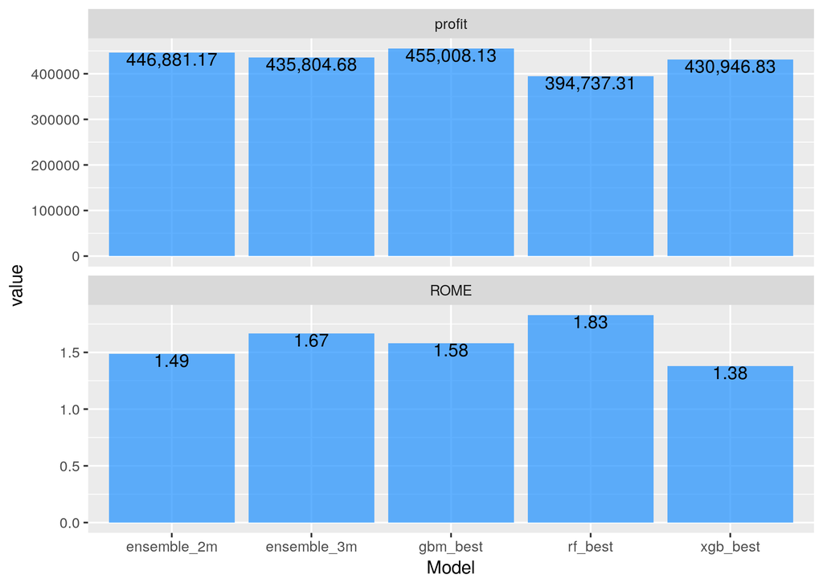

```r
final_eval <- intuit75k %>%
  filter(training == 0) %>%
  select(id, res1)

rf_preds <- readRDS("data/rf_preds.rds")
rf_best <- rf_preds[,5]

gbm_best <- readRDS("data/pred_gbm.rds")

xgb_best <- readRDS("data/xgb_best.rds")

# ensemble probabilities from 2 best and 3 best models
ensemble_2m <- (gbm_best + xgb_best)/2
ensemble_3m <- (gbm_best + xgb_best + rf_best)/3

# comparison among 3 best predictions from each type of algorigthms
final_eval <- cbind(final_eval, rf_best, gbm_best, xgb_best, ensemble_2m, ensemble_3m)
vars <- c("rf_best", "gbm_best", "xgb_best", "ensemble_2m", "ensemble_3m")
eval_df <- model_eval(final_eval, vars)


eval_df %>%
  select(var, profit, ROME) %>%
  gather(key = "measure", value = value, - var) %>%
  ggplot(aes(x = var, y = value)) +
  geom_bar(stat = "identity", fill = "dodgerblue1", alpha = 0.7) +
  facet_wrap(~measure,scales= "free_y",ncol= 1)+
  geom_text(aes(label=format_nr(value,mark = ",",dec= 2)), vjust = 1) +
  labs(main = "Profit & ROME Comparison",
       x = "Model")
```

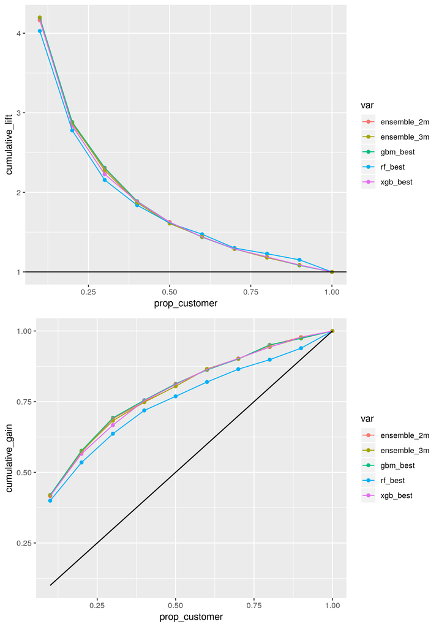

```r
lift_gain_plot(final_eval, vars)
```

```r
cm_df <- cm(final_eval, vars)
cm_df[,2:3] <- lapply(cm_df[,2:3], as.numeric)
cm_df
```

```
          var       auc       tpr
1     rf_best 0.7414784 0.7017226
2    gbm_best 0.7677052 0.8567543
3    xgb_best 0.7627369 0.8667271
4 ensemble_2m 0.7663956 0.8640073
5 ensemble_3m 0.7628152 0.8168631
```

From profit and ROME comparisons we can see that GBM model performs the best in terms of expected profits. Though random forest has the highest ROME, it has higher risk of missing potential customers. Therefore, we favor the model with highest expected profits. In lift and gain charts, all gradient based models perform quite similar while random forest performs the worst. In confusion matrix table, GBM has the highest AUC but medium TPR. Therefore, we use predicted probabilities in GBM model to determine whom to mail during wave-2 promotions.

```r
targets <- final_eval %>%
  mutate(mailto_wave2 = ifelse(res1 =="Yes", "FALSE",
                               ifelse(gbm_best > 2*breakeven_rate, "TRUE", "FALSE"))) %>%
  select(id, mailto_wave2)

saveRDS(targets, "data/Menghui_Shumeng_Wenrui_Group10.rds")
```